# Capital BikeShare System Data Exploration Part II

### by Clarence Beling

## Investigation Overview

In this investigation, we wanted to look at the characteristics of bikes that could be used to predict the best performances. The main focus was on this four things : time, type, races and its participants count.

## Dataset Overview

The data consisted of information regarding 158,130 bike records by race, including times, stations and bike qualities. This is a Washington DC Metro Area dataset of February 2019, but we needed extraction of bikes and races data, due to incompleteness of information, to continue exploration.

## Distribution of Biker Types

In the three dataset, biker type has two variables whose Member is majority and Casual is minority.

1) The first plot show the participation in the whole tournament ;

2) The second plot show the bikes of the tournament ;

3) The third plot show the winners of the tournament.

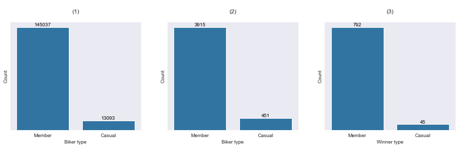

## Distribution of Durations

In the main dataset, durations has a long-tail distribution, with many short-time bikers and few long-time bikers. When plotted on a logarithmic scale, this distribution appears roughly unimodal, with a peak between 350 and 1,000.

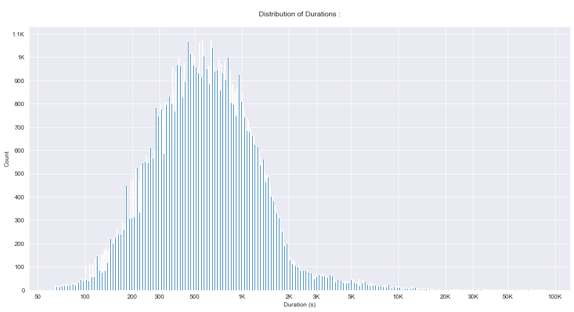

## Distribution Durations vs Biker types

There we used three differents plots to view differents values of biker type in the main dataset, with the two maxs going over 80,000. In the violinplot, we can see that the Member biker type is larger than the Casual biker type. The boxplot show the values of the description (max, std, 75%, 50%, 25% and min). And there is averages of those two values in the barplot.

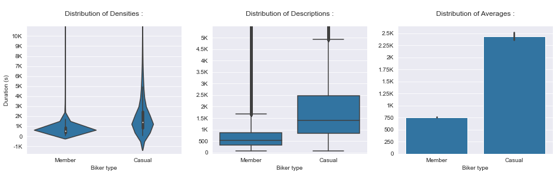

## Distribution of Races vs Participants vs Biker types

In the race dataset, we plotted the lines of races and their participants. We can see in this distribution that each biker type decrease as the races follow each another.

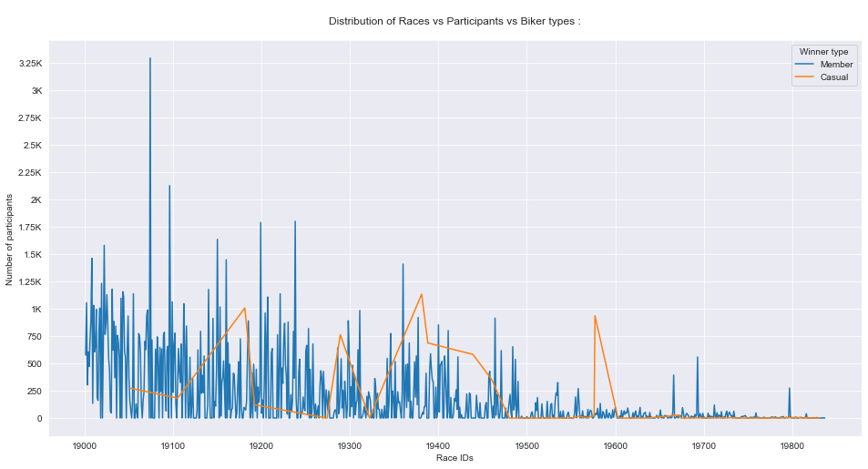

## Distribution of Races vs Winners Times vs Biker types

In race dataset, we plotted in a logarithmic scale the winner time distribution. It show us its linearity with races accross biker type. We can see Member biker type along but Casual biker type show up as line progress.

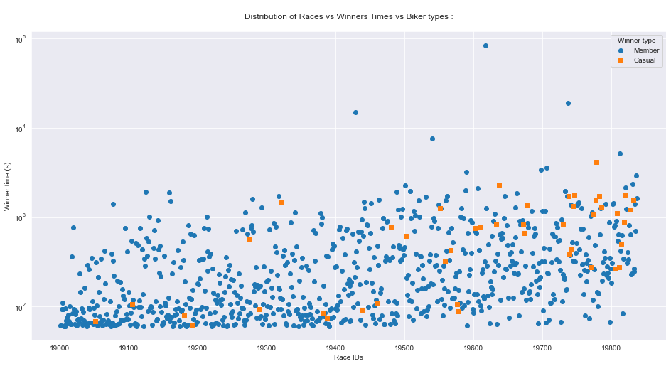